# Stat 184 Final Project

**Setup**

```r
rm(list = ls()) #clear the workspace

library(Stat2Data)
library(tidyverse)
library(mosaic)
library(ggformula)
library(car)
library(leaps)
library(tinytex)
library(mosaic)
library(ggformula)
library(tidyverse)
library(car)
library(tinytex)
```

# The question we are researching is “Which statistic has the greatest impact on winning games in the MLB?”

## Our primary dataset is the Teams table in Sean Lahman’s Baseball Database, which is a downloadable CSV. We found the dataset by Googling sets that contained baseball data, and this page was the top hit. There are many different tables in the data package but Teams table had the most information relevant to our research question. The database was created by Sean Lahman in 1994, who wanted to make baseball statistics freely available to the general public. Although it started with just Lahman, it has grown tremendously and there is now a full team of researchers dedicated to collecting and maintaining the most accurate public source for baseball stats. In the Teams dataset, each case represents a single team from a specified season. There are 3,015 total cases in this data table, dating back to the 1871 season. The Teams dataset does not have a win percentage variable defined, so we mutated a variable by dividing wins in a season by the total games played. We evaluated the relationships between this new win percentage variables with team statistics such as runs scored, home runs, walks, ERA, strikeouts alowed, runs allowed, errors, stolen bases, batting average, and on base percentage. We calculated batting average by dividing the hits a team had in a season by the total amount of at-bats, and did the same for on base percentage, dividing Hits + walks bt the amount of at bats.

## The second dataset we used is called MLB Standings in 2016, and it comes from the Stat2Data package. Adam used it in one of his other classes and has already worked with this dataset, so we have some familiarity with the package. The dataset includes the batting statistics for each team from the 2016 MLB season. Unlike the primary source, it provides win percentage, batting average, and other offensive stats that were left out of the previous data table. This data set focuses on just one MLB season. We used variables that we found had the greatest impact on winpct from the prary data. There are 30 total cases, with a case being a particular team in the MLB and the variables are different metrics of their performance from that season. The data was collected and maintained by a large group of collaborators and sources that work on the BaseballReference webpage.

## The third dataset we chose to evaluate contains the batting and pitching statistics from the 2023 MLB season. This is the most recent MLB season and it was not included in our primary data source, which only covered the years 1871 to 2022. This data came from www.baseballreference.com, which is collected and maintained by a large group of collaborators and sources that work on the BaseballReference webpage, just as it was for the secondary data source. There are 30 total cases, each representing one team in 2023, and there are 64 different variables available.

#### Primary data

```r
rawbaseball_data <- read_csv("/Users/dhruv/Downloads/baseballstats.csv")
calculateBA <- function(x,y){round((x/y), digits = 3)}
calculateOBP <- function(x,y,z){round((x+z)/y, digits = 3)}
#Filtering Raw data into data after 1973, Mutate WINPCT, BA, and OBP variables.
#Use transformation Functions for mutations
baseballdata <- rawbaseball_data%>%
  mutate(winpct = as.numeric(round(W/G, digits = 3)))%>%
  mutate(BA = as.numeric(calculateBA(H,AB)))%>%
  mutate(OBP = as.numeric(calculateOBP(H,AB,BB)))%>%
  #mutate(OBP = as.numeric((H+BB)/AB))%>%
  filter(yearID > 1973)

#Filter National league data for 2021 and 2022, mutating the same 3 variables as in baseballdata
#Use transormation Functions for mutations
NLbaseballdata2122 <- rawbaseball_data%>%
  mutate(winpct = as.numeric(W/G))%>%
  mutate(BA = as.numeric(calculateBA(H,AB)))%>%
  mutate(OBP = as.numeric((calculateOBP(H,AB,BB))))%>%
  filter(yearID >= 2021, lgID == "NL")

#display head of each data frame
head(rawbaseball_data)
```

| yearID | lgID | teamID | franchID | divID | Rank | G | Ghome | W | L | DivWin | WCWin | LgWin | WSWin | R | AB | H | 2B | 3B | HR | BB | SO | SB | CS | HBP | SF | RA | ER | ERA | CG | … |
| --- | --- | --- | --- | --- | --- | --- | --- | --- | --- | --- | --- | --- | --- | --- | --- | --- | --- | --- | --- | --- | --- | --- | --- | --- | --- | --- | --- | --- | --- | --- |
| 1871 | NA | BS1 | BNA | NA | 3 | 31 | NA | 20 | 10 | NA | NA | N | NA | 401 | 1372 | 426 | 70 | 37 | 3 | 60 | 19 | 73 | 16 | NA | NA | 303 | 109 | 3.55 | 22 | … |
| 1871 | NA | CH1 | CNA | NA | 2 | 28 | NA | 19 | 9 | NA | NA | N | NA | 302 | 1196 | 323 | 52 | 21 | 10 | 60 | 22 | 69 | 21 | NA | NA | 241 | 77 | 2.76 | 25 | … |
| 1871 | NA | CL1 | CFC | NA | 8 | 29 | NA | 10 | 19 | NA | NA | N | NA | 249 | 1186 | 328 | 35 | 40 | 7 | 26 | 25 | 18 | 8 | NA | NA | 341 | 116 | 4.11 | 23 | … |
| 1871 | NA | FW1 | KEK | NA | 7 | 19 | NA | 7 | 12 | NA | NA | N | NA | 137 | 746 | 178 | 19 | 8 | 2 | 33 | 9 | 16 | 4 | NA | NA | 243 | 97 | 5.17 | 19 | … |
| 1871 | NA | NY2 | NNA | NA | 5 | 33 | NA | 16 | 17 | NA | NA | N | NA | 302 | 1404 | 403 | 43 | 21 | 1 | 33 | 15 | 46 | 15 | NA | NA | 313 | 121 | 3.72 | 32 | … |
| 1871 | NA | PH1 | PNA | NA | 1 | 28 | NA | 21 | 7 | NA | NA | Y | NA | 376 | 1281 | 410 | 66 | 27 | 9 | 46 | 23 | 56 | 12 | NA | NA | 266 | 137 | 4.95 | 27 | … |

```r
head(baseballdata)
```

| yearID | lgID | teamID | franchID | divID | Rank | G | Ghome | W | L | DivWin | WCWin | LgWin | WSWin | R | AB | H | 2B | 3B | HR | BB | SO | SB | CS | HBP | SF | RA | ER | ERA | CG | … |
| --- | --- | --- | --- | --- | --- | --- | --- | --- | --- | --- | --- | --- | --- | --- | --- | --- | --- | --- | --- | --- | --- | --- | --- | --- | --- | --- | --- | --- | --- | --- |
| 1974 | NL | ATL | ATL | W | 3 | 163 | 81 | 88 | 74 | N | NA | N | N | 661 | 5533 | 1375 | 202 | 37 | 120 | 571 | 772 | 72 | 44 | 24 | 42 | 563 | 500 | 3.05 | 46 | … |
| 1974 | AL | BAL | BAL | E | 1 | 162 | 81 | 91 | 71 | Y | NA | N | N | 659 | 5535 | 1418 | 226 | 27 | 116 | 509 | 770 | 145 | 58 | 58 | 56 | 612 | 536 | 3.27 | 57 | … |
| 1974 | AL | BOS | BOS | E | 3 | 162 | 81 | 84 | 78 | N | NA | N | N | 696 | 5499 | 1449 | 236 | 31 | 109 | 569 | 811 | 104 | 58 | 33 | 49 | 661 | 601 | 3.72 | 71 | … |
| 1974 | AL | CAL | ANA | W | 6 | 163 | 81 | 68 | 94 | N | NA | N | N | 618 | 5401 | 1372 | 203 | 31 | 95 | 509 | 801 | 119 | 79 | 45 | 48 | 657 | 563 | 3.52 | 64 | … |
| 1974 | AL | CHA | CHW | W | 4 | 163 | 82 | 80 | 80 | N | NA | N | N | 684 | 5577 | 1492 | 225 | 23 | 135 | 519 | 858 | 64 | 53 | 26 | 43 | 721 | 641 | 3.94 | 55 | … |
| 1974 | NL | CHN | CHC | E | 6 | 162 | 81 | 66 | 96 | N | NA | N | N | 669 | 5574 | 1397 | 221 | 42 | 110 | 621 | 857 | 78 | 73 | 29 | 40 | 826 | 697 | 4.28 | 23 | … |

```r
head(NLbaseballdata2122)
```

| yearID | lgID | teamID | franchID | divID | Rank | G | Ghome | W | L | DivWin | WCWin | LgWin | WSWin | R | AB | H | 2B | 3B | HR | BB | SO | SB | CS | HBP | SF | RA | ER | ERA | CG | … |
| --- | --- | --- | --- | --- | --- | --- | --- | --- | --- | --- | --- | --- | --- | --- | --- | --- | --- | --- | --- | --- | --- | --- | --- | --- | --- | --- | --- | --- | --- | --- |
| 2021 | NL | ARI | ARI | W | 5 | 162 | 81 | 52 | 110 | N | N | N | N | 679 | 5489 | 1297 | 308 | 31 | 144 | 537 | 1465 | 43 | 16 | 54 | 28 | 893 | 804 | 5.11 | 3 | … |
| 2021 | NL | ATL | ATL | E | 1 | 161 | 80 | 88 | 73 | Y | N | Y | Y | 790 | 5363 | 1307 | 269 | 20 | 239 | 549 | 1453 | 59 | 19 | 67 | 43 | 656 | 608 | 3.88 | 2 | … |
| 2021 | NL | CHN | CHC | C | 4 | 162 | 81 | 71 | 91 | N | N | N | N | 705 | 5306 | 1255 | 225 | 26 | 210 | 502 | 1596 | 86 | 37 | 92 | 30 | 839 | 765 | 4.87 | 1 | … |
| 2021 | NL | CIN | CIN | C | 3 | 162 | 81 | 83 | 79 | N | N | N | N | 786 | 5423 | 1352 | 295 | 13 | 222 | 553 | 1425 | 36 | 24 | 105 | 45 | 760 | 702 | 4.40 | 1 | … |
| 2021 | NL | COL | COL | W | 4 | 161 | 81 | 74 | 87 | N | N | N | N | 739 | 5374 | 1338 | 275 | 34 | 182 | 491 | 1356 | 76 | 23 | 58 | 36 | 796 | 748 | 4.82 | 3 | … |
| 2021 | NL | LAN | LAD | W | 2 | 162 | 81 | 106 | 56 | N | Y | N | N | 830 | 5445 | 1330 | 247 | 24 | 237 | 613 | 1408 | 65 | 17 | 104 | 45 | 561 | 486 | 3.01 | 1 | … |

```r
model <- (baseballdata$winpct ~ baseballdata$BA + baseballdata$ERA)
summary(model)
```

```
 Length   Class    Mode
      3 formula    call
```

#### Secondary Data

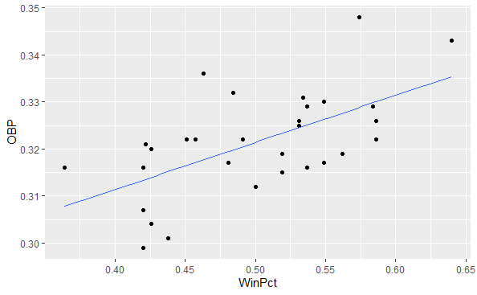

```r
#load package with dataset
library(Stat2Data)

data2 <- data("MLBStandings2016")

gf_point(OBP~ WinPct, data = MLBStandings2016) %>% gf_lm()
```

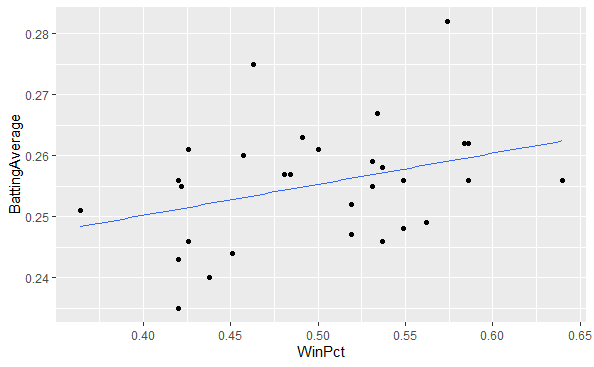

```r
gf_point(BattingAverage~ WinPct, data = MLBStandings2016) %>% gf_lm()
```

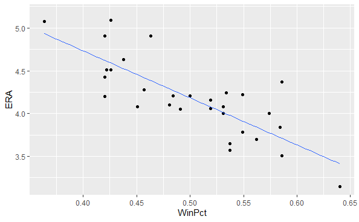

```r
gf_point(ERA~ WinPct, data = MLBStandings2016) %>% gf_lm()
```

```r
#mutate
#MLBStandings2016 %>%
  #mutate(rank = rank(desc(count())))

head(MLBStandings2016)
```

|  | Team | League | Wins | Losses | WinPct | BattingAverage | Runs | Hits | HR | Doubles | Triples | RBI | SB | OBP | SLG | ERA | HitsAllowed | Walks | StrikeOuts | Saves | WHIP |
| --- | --- | --- | --- | --- | --- | --- | --- | --- | --- | --- | --- | --- | --- | --- | --- | --- | --- | --- | --- | --- | --- |
| 1 | Arizona Diamondbacks | NL | 69 | 93 | 0.426 | 0.261 | 752 | 1479 | 190 | 285 | 56 | 709 | 137 | 0.320 | 0.432 | 5.09 | 1563 | 603 | 1318 | 31 | 1.492 |
| 2 | Atlanta Braves | NL | 68 | 93 | 0.422 | 0.255 | 649 | 1404 | 122 | 295 | 27 | 615 | 75 | 0.321 | 0.384 | 4.51 | 1414 | 547 | 1227 | 39 | 1.355 |
| 3 | Baltimore Orioles | AL | 89 | 73 | 0.549 | 0.256 | 744 | 1413 | 253 | 265 | 6 | 710 | 19 | 0.317 | 0.443 | 4.22 | 1408 | 545 | 1248 | 54 | 1.364 |
| 4 | Boston Red Sox | AL | 93 | 69 | 0.574 | 0.282 | 878 | 1598 | 208 | 343 | 25 | 836 | 83 | 0.348 | 0.461 | 4.00 | 1342 | 490 | 1362 | 43 | 1.273 |
| 5 | Chicago Cubs | NL | 103 | 58 | 0.640 | 0.256 | 808 | 1409 | 199 | 293 | 30 | 767 | 66 | 0.343 | 0.429 | 3.15 | 1125 | 495 | 1441 | 38 | 1.110 |
| 6 | Chicago White Sox | AL | 78 | 84 | 0.481 | 0.257 | 686 | 1428 | 168 | 277 | 33 | 656 | 77 | 0.317 | 0.410 | 4.10 | 1422 | 521 | 1270 | 43 | 1.343 |

## Third data source

```r
batter_data2023 <- read_csv("/Users/dhruv/Downloads/2023batting.csv")
pitcher_data2023 <- read_csv("/Users/dhruv/Downloads/2023pitching.csv")
baseballdata2023 <- full_join(x = batter_data2023, y = pitcher_data2023, by = "Tm")

head(baseballdata2023)
```

| Tm | #Bat | BatAge | R/G | G.x | PA | AB | R.x | H.x | 2B | 3B | HR.x | RBI | SB | CS | BB.x | SO.x | BA | OBP | SLG | OPS | OPS+ | TB | GDP | HBP.x | SH | SF | IBB.x | LOB.x | #P | … |
| --- | --- | --- | --- | --- | --- | --- | --- | --- | --- | --- | --- | --- | --- | --- | --- | --- | --- | --- | --- | --- | --- | --- | --- | --- | --- | --- | --- | --- | --- | --- |
| Arizona Diamondbacks | 54 | 27.4 | 4.60 | 162 | 6124 | 5436 | 746 | 1359 | 274 | 44 | 166 | 706 | 166 | 26 | 540 | 1247 | 0.250 | 0.322 | 0.408 | 0.730 | 98 | 2219 | 121 | 58 | 36 | 50 | 11 | 1091 | 34 | … |
| Atlanta Braves | 53 | 27.9 | 5.85 | 162 | 6249 | 5597 | 947 | 1543 | 293 | 23 | 307 | 916 | 132 | 27 | 538 | 1289 | 0.276 | 0.344 | 0.501 | 0.845 | 124 | 2803 | 128 | 67 | 2 | 43 | 20 | 1062 | 32 | … |
| Baltimore Orioles | 50 | 27.3 | 4.98 | 162 | 6123 | 5495 | 807 | 1399 | 309 | 28 | 183 | 780 | 114 | 24 | 512 | 1370 | 0.255 | 0.321 | 0.421 | 0.742 | 107 | 2313 | 114 | 45 | 21 | 47 | 14 | 1041 | 31 | … |
| Boston Red Sox | 56 | 28.6 | 4.77 | 162 | 6174 | 5562 | 772 | 1437 | 339 | 19 | 182 | 734 | 112 | 26 | 486 | 1372 | 0.258 | 0.324 | 0.424 | 0.748 | 100 | 2360 | 118 | 71 | 11 | 35 | 15 | 1117 | 33 | … |
| Chicago Cubs | 48 | 28.4 | 5.06 | 162 | 6220 | 5504 | 819 | 1399 | 269 | 30 | 196 | 786 | 140 | 34 | 570 | 1391 | 0.254 | 0.330 | 0.421 | 0.751 | 101 | 2316 | 95 | 77 | 15 | 52 | 11 | 1127 | 27 | … |
| Chicago White Sox | 56 | 27.8 | 3.96 | 162 | 5980 | 5501 | 641 | 1308 | 264 | 13 | 171 | 617 | 86 | 22 | 377 | 1424 | 0.238 | 0.291 | 0.384 | 0.675 | 83 | 2111 | 122 | 52 | 16 | 29 | 19 | 1009 | 32 | … |

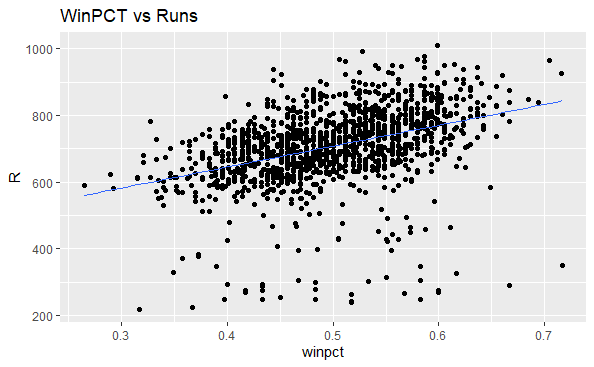

```r
#Winpct vs Runs
gf_point(R ~ winpct, data = baseballdata) %>% gf_lm() + labs(title= "WinPCT vs Runs")
```

```r
Runmdl <- lm(R~winpct, data = baseballdata)
summary(Runmdl)
```

```
Call:
lm(formula = R ~ winpct, data = baseballdata)

Residuals:
    Min      1Q  Median      3Q     Max
-523.59  -42.57    8.61   59.47  267.74

Coefficients:
            Estimate Std. Error t value Pr(>|t|)
(Intercept)   393.53      19.98   19.70   <2e-16 ***
winpct        628.28      39.57   15.88   <2e-16 ***
---
Signif. codes:  0 ‘***’ 0.001 ‘**’ 0.01 ‘*’ 0.05 ‘.’ 0.1 ‘ ’ 1

Residual standard error: 105.4 on 1376 degrees of freedom
Multiple R-squared:  0.1549,    Adjusted R-squared:  0.1542
F-statistic: 252.1 on 1 and 1376 DF,  p-value: < 2.2e-16
```

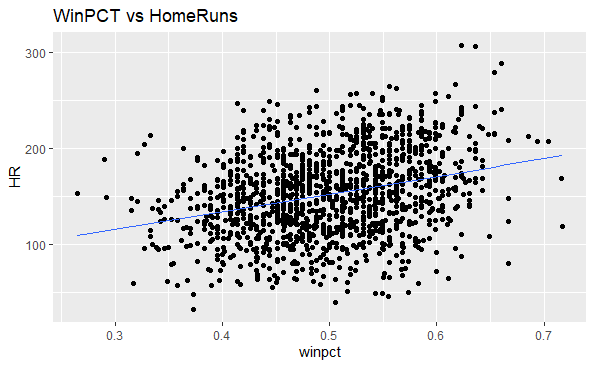

```r
#Winpct vs Home Runs
gf_point(HR ~ winpct, data = baseballdata) %>% gf_lm() + labs(title= "WinPCT vs HomeRuns")
```

```r
HRmdl <- lm(HR ~ winpct, data = baseballdata)
summary(HRmdl)
```

```
Call:
lm(formula = HR ~ winpct, data = baseballdata)

Residuals:
     Min       1Q   Median       3Q      Max
-117.194  -29.268   -0.306   28.240  132.243

Coefficients:
            Estimate Std. Error t value Pr(>|t|)
(Intercept)   59.659      8.003   7.454 1.59e-13 ***
winpct       184.747     15.851  11.656  < 2e-16 ***
---
Signif. codes:  0 ‘***’ 0.001 ‘**’ 0.01 ‘*’ 0.05 ‘.’ 0.1 ‘ ’ 1

Residual standard error: 42.22 on 1376 degrees of freedom
Multiple R-squared:  0.08986,   Adjusted R-squared:  0.0892
F-statistic: 135.9 on 1 and 1376 DF,  p-value: < 2.2e-16
```

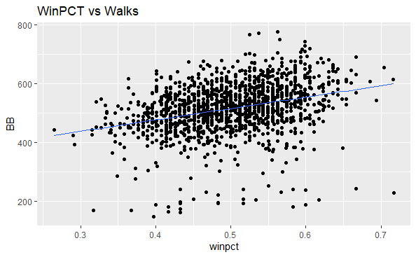

```r
#Winpct vs Walks
gf_point(BB ~ winpct, data = baseballdata) %>% gf_lm() + labs(title= "WinPCT vs Walks")
```

```r
BBmdl <- lm(BB~ winpct, data = baseballdata)
summary(BBmdl)
```

```
Call:
lm(formula = BB ~ winpct, data = baseballdata)

Residuals:
    Min      1Q  Median      3Q     Max
-370.70  -39.21    4.41   51.64  241.12

Coefficients:
            Estimate Std. Error t value Pr(>|t|)
(Intercept)   320.57      15.75   20.35   <2e-16 ***
winpct        387.92      31.20   12.43   <2e-16 ***
---
Signif. codes:  0 ‘***’ 0.001 ‘**’ 0.01 ‘*’ 0.05 ‘.’ 0.1 ‘ ’ 1

Residual standard error: 83.09 on 1376 degrees of freedom
Multiple R-squared:  0.101, Adjusted R-squared:  0.1004
F-statistic: 154.6 on 1 and 1376 DF,  p-value: < 2.2e-16
```

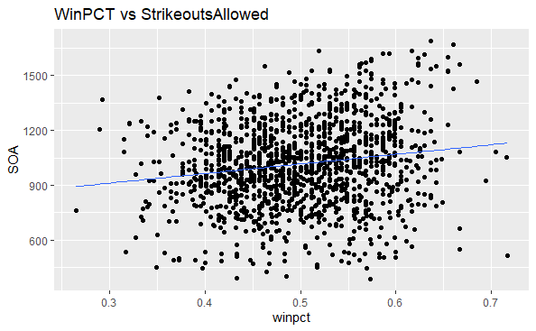

```r
#Winpct vs Strike Outs Allowed
gf_point(SOA~ winpct, data = baseballdata) %>% gf_lm() + labs(title= "WinPCT vs StrikeoutsAllowed")
```

```r
SOAmdl <- lm(SOA~ winpct, data = baseballdata)
summary(SOAmdl)
```

```
Call:
lm(formula = SOA ~ winpct, data = baseballdata)

Residuals:
    Min      1Q  Median      3Q     Max
-666.53 -148.50   -9.98  155.41  606.79

Coefficients:
            Estimate Std. Error t value Pr(>|t|)
(Intercept)   754.04      43.45  17.355  < 2e-16 ***
winpct        524.43      86.05   6.094 1.42e-09 ***
---
Signif. codes:  0 ‘***’ 0.001 ‘**’ 0.01 ‘*’ 0.05 ‘.’ 0.1 ‘ ’ 1

Residual standard error: 229.2 on 1376 degrees of freedom
Multiple R-squared:  0.02628,   Adjusted R-squared:  0.02558
F-statistic: 37.14 on 1 and 1376 DF,  p-value: 1.424e-09
```

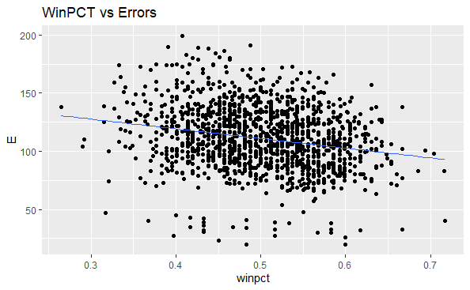

```r
#Winpct vs Errors
gf_point(E~ winpct, data = baseballdata) %>% gf_lm() + labs(title= "WinPCT vs Errors")
```

```r
Emdl <- lm(E~ winpct, data = baseballdata)
summary(Emdl)
```

```
Call:
lm(formula = E ~ winpct, data = baseballdata)

Residuals:
    Min      1Q  Median      3Q     Max
-92.602 -17.836  -0.937  17.793  80.231

Coefficients:
            Estimate Std. Error t value Pr(>|t|)
(Intercept)  152.675      4.961  30.772   <2e-16 ***
winpct       -83.307      9.826  -8.478   <2e-16 ***
---
Signif. codes:  0 ‘***’ 0.001 ‘**’ 0.01 ‘*’ 0.05 ‘.’ 0.1 ‘ ’ 1

Residual standard error: 26.17 on 1376 degrees of freedom
Multiple R-squared:  0.04964,   Adjusted R-squared:  0.04895
F-statistic: 71.88 on 1 and 1376 DF,  p-value: < 2.2e-16
```

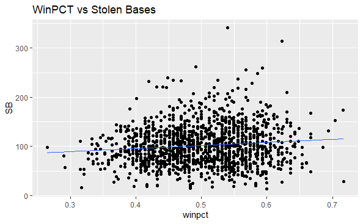

```r
#Winpct vs Stolen Bases
gf_point(SB~ winpct, data = baseballdata) %>% gf_lm() + labs(title= "WinPCT vs Stolen Bases")
```

```r
SBmdl <- lm(SB~ winpct, data = baseballdata)
summary(SBmdl)
```

```
Call:
lm(formula = SB ~ winpct, data = baseballdata)

Residuals:
    Min      1Q  Median      3Q     Max
-94.246 -28.324  -3.631  24.249 236.519

Coefficients:
            Estimate Std. Error t value Pr(>|t|)
(Intercept)   70.590      7.631   9.251  < 2e-16 ***
winpct        62.761     15.113   4.153 3.48e-05 ***
---
Signif. codes:  0 ‘***’ 0.001 ‘**’ 0.01 ‘*’ 0.05 ‘.’ 0.1 ‘ ’ 1

Residual standard error: 40.25 on 1376 degrees of freedom
Multiple R-squared:  0.01238,   Adjusted R-squared:  0.01166
F-statistic: 17.25 on 1 and 1376 DF,  p-value: 3.485e-05
```

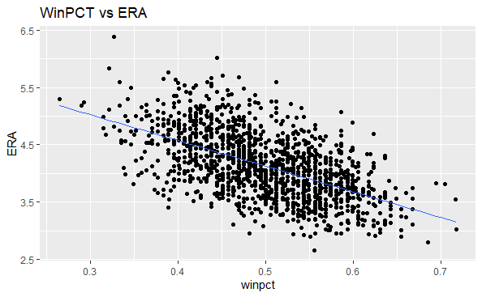

```r
#Winpct vs Earned Run Average
gf_point(ERA~ winpct, data = baseballdata) %>% gf_lm() + labs(title= "WinPCT vs ERA")
```

```r
ERAmdl <- lm(ERA~ winpct, data = baseballdata)
summary(ERAmdl)
```

```
Call:
lm(formula = ERA ~ winpct, data = baseballdata)

Residuals:
     Min       1Q   Median       3Q      Max
-1.26044 -0.33077 -0.00969  0.29858  1.63379

Coefficients:
            Estimate Std. Error t value Pr(>|t|)
(Intercept)  6.36537    0.08833   72.06   <2e-16 ***
winpct      -4.48010    0.17495  -25.61   <2e-16 ***
---
Signif. codes:  0 ‘***’ 0.001 ‘**’ 0.01 ‘*’ 0.05 ‘.’ 0.1 ‘ ’ 1

Residual standard error: 0.466 on 1376 degrees of freedom
Multiple R-squared:  0.3228,    Adjusted R-squared:  0.3223
F-statistic: 655.8 on 1 and 1376 DF,  p-value: < 2.2e-16
```

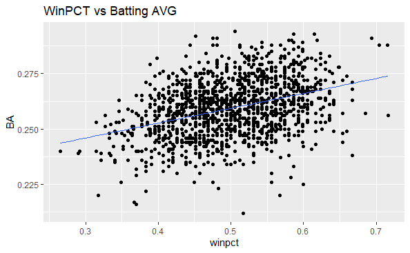

```r
#Winpct vs Batting Average
gf_point(BA~ winpct, data = baseballdata) %>% gf_lm() + labs(title= "WinPCT vs Batting AVG")
```

```r
BAmdl <- lm(BA~ winpct, data = baseballdata)
summary(BAmdl)
```

```
Call:
lm(formula = BA ~ winpct, data = baseballdata)

Residuals:
      Min        1Q    Median        3Q       Max
-0.048490 -0.008071  0.000266  0.007828  0.035938

Coefficients:
            Estimate Std. Error t value Pr(>|t|)
(Intercept) 0.225803   0.002238  100.91   <2e-16 ***
winpct      0.067093   0.004432   15.14   <2e-16 ***
---
Signif. codes:  0 ‘***’ 0.001 ‘**’ 0.01 ‘*’ 0.05 ‘.’ 0.1 ‘ ’ 1

Residual standard error: 0.0118 on 1376 degrees of freedom
Multiple R-squared:  0.1428,    Adjusted R-squared:  0.1422
F-statistic: 229.2 on 1 and 1376 DF,  p-value: < 2.2e-16
```

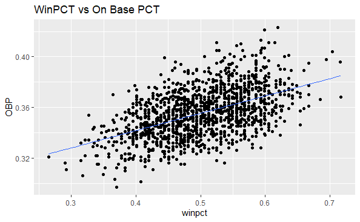

```r
#Winpct vs On Base Percentage
gf_point(OBP~ winpct, data = baseballdata) + geom_lm() + labs(title= "WinPCT vs On Base PCT")
```

```r
OBPmdl <- lm(OBP~ winpct, data = baseballdata)
summary(OBPmdl)
```

```
Call:
lm(formula = OBP ~ winpct, data = baseballdata)

Residuals:
      Min        1Q    Median        3Q       Max
-0.044404 -0.011161 -0.000772  0.010596  0.052237

Coefficients:
            Estimate Std. Error t value Pr(>|t|)
(Intercept) 0.286974   0.003095   92.71   <2e-16 ***
winpct      0.136741   0.006130   22.30   <2e-16 ***
---
Signif. codes:  0 ‘***’ 0.001 ‘**’ 0.01 ‘*’ 0.05 ‘.’ 0.1 ‘ ’ 1

Residual standard error: 0.01633 on 1376 degrees of freedom
Multiple R-squared:  0.2656,    Adjusted R-squared:  0.265
F-statistic: 497.5 on 1 and 1376 DF,  p-value: < 2.2e-16
```

### Since there has recently been a rule change in the MLB, adding a designated hitter to the National League as of 2022, we decided to compare the impact of Batting average and ERA on win percentage for these National League teams in both the 2021 and 2022 season.

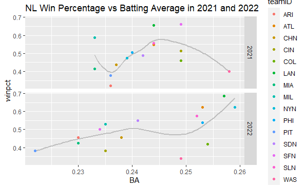

```r
# 2021 National League Data
NLbaseball2021 <- NLbaseballdata2122%>%
  filter(yearID == 2021)

# 2022 National League Data
NLbaseball2022 <- NLbaseballdata2122%>%
  filter(yearID == 2022)

# Batting average vs winpct in 2021 and 2022
ggplot(NLbaseballdata2122, aes(x = BA, y = winpct, color = teamID)) + geom_smooth(se = F, color = "grey") + geom_point() + facet_grid(yearID ~ .) + labs( title = "NL Win Percentage vs Batting Average in 2021 and 2022")
```

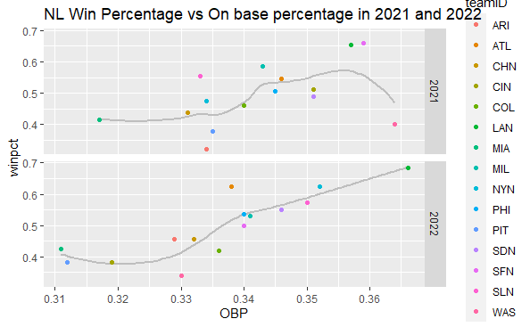

```r
# On base pct vs winpct in 2021 and 2022
ggplot(NLbaseballdata2122, aes(x = OBP, y = winpct, color = teamID)) + geom_smooth(se = F, color = "grey") + geom_point() + facet_grid(yearID ~ .) + labs( title = "NL Win Percentage vs On base percentage in 2021 and 2022")
```

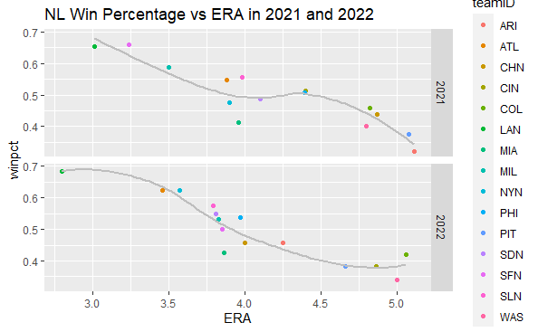

```r
# ERA vs winpct in 2021 and 2022
ggplot(NLbaseballdata2122, aes(x = ERA, y = winpct, color = teamID)) + geom_point() + geom_smooth(se = F, color = "grey") + facet_grid(yearID ~ .) + labs( title = "NL Win Percentage vs ERA in 2021 and 2022")
```

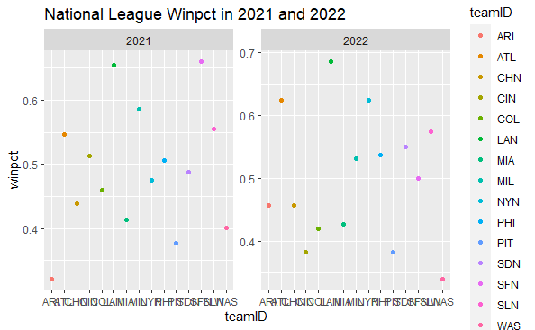

```r
#WinPCT. by team in 2021 and 2022
NLbaseballdata2122 %>%
  ggplot(aes(x = teamID, y = winpct, color = teamID)) +
  geom_point() +  # Use points to represent the data
  facet_wrap(~yearID, scales = "free") +
  labs(title = "National League Winpct in 2021 and 2022")
```

### Looking at these plots, we can conclude that with the rule change going into the 2022 season, batting average and OBP had a stronger relationship to win percentage than it had in 2021, while the relationship between winpct and ERA remained nearly the same.

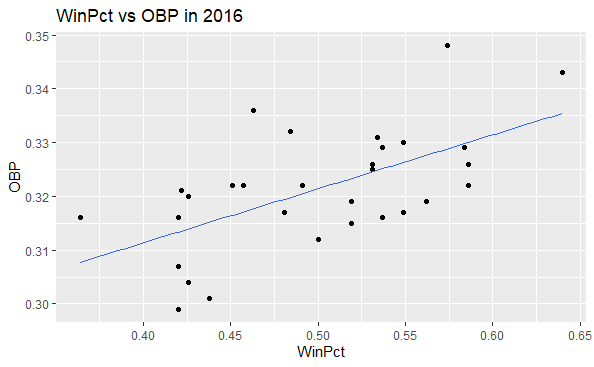

```r
gf_point(OBP~ WinPct, data = MLBStandings2016) %>% gf_lm() + labs(title = "WinPct vs OBP in 2016")
```

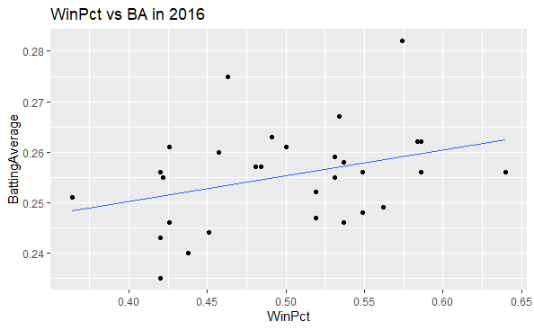

```r
gf_point(BattingAverage~ WinPct, data = MLBStandings2016) %>% gf_lm() + labs(title = "WinPct vs BA in 2016")
```

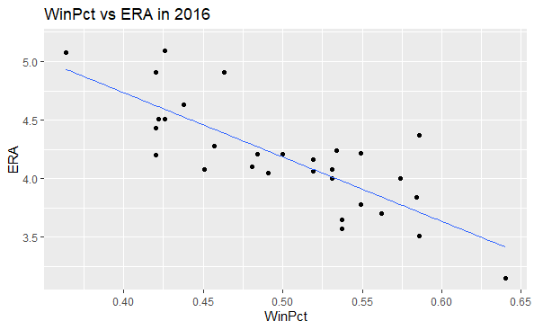

```r
gf_point(ERA~ WinPct, data = MLBStandings2016) %>% gf_lm() + labs(title = "WinPct vs ERA in 2016")
```

### From these graphs, we can see that On base percentage and ERA had a stronger relationship with Win Percentage in the 2016 season than Batting Average did.

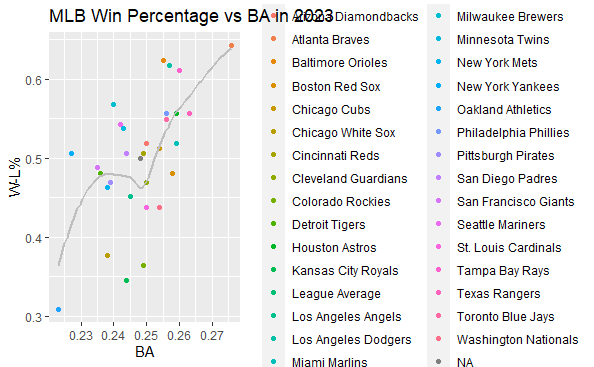

```r
ggplot(baseballdata2023, aes(x = BA, y = `W-L%`, color = Tm)) + geom_point() + geom_smooth(se = F, color = "grey") + labs( title = "MLB Win Percentage vs BA in 2023")
```

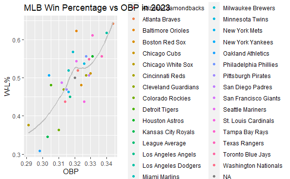

```r
ggplot(baseballdata2023, aes(x = OBP, y = `W-L%`, color = Tm)) + geom_point() + geom_smooth(se = F, color = "grey") + labs( title = "MLB Win Percentage vs OBP in 2023")
```

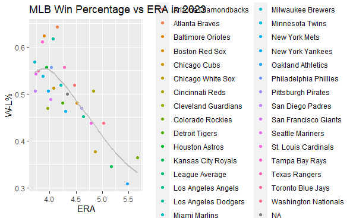

```r
ggplot(baseballdata2023, aes(x = ERA, y = `W-L%`, color = Tm)) + geom_point() + geom_smooth(se = F, color = "grey") + labs( title = "MLB Win Percentage vs ERA in 2023")
```

## When visualized, the data tends to be consistent with the conclusions we were able to come to earlier. All three of the chosen statistcs appear to have strong relationships with win percentage, with OBP having the greatest magnitude. OBP and BA both have significant positive relationships with winpct, while ERA has a strong negative relationship.

## The biggest challenge we ran into during this project was figuring out how we were goung to include all of the necessary elements from the Final Check Sheet. We had already completed our Final Presentation, but had used a lot of similar graphics and simple data wrangling techniques, so we had to adjust and spend some time to include more of the elements that were on the check sheet. Prior to this challenge, we had been working pretty smoothly, with our biggest issue being figuring out how we were going to mutate the statistics we wanted to be included that were not in our chosen datasets. We researched how these MLB stats, Batting Average and OBP, are calculated and use the neccessary information to create user-defined functions, which we were able to use to calculate and mutate these stats into our data tables.

# Final Conclusions

## Our third data source, like our second, took a look at an individual season. This data set includes all of the team batting and pitching statistics in the most recent MLB season. Just as we did for 2016, we evaluated how Batting average, On base percentage, and ERA impacted win percentage for the season. On base percentage appears to have the strongest relationship with win percentage in 2023, while ERA appears to have a slightly weaker relationship than in our other evaluations.